# Reddit Question - Aggregation

thaufas

10/10/2021

## Overview

**Source**: [Reddit.com/r/Rlanguage | Noob question: how do I combine data?](https://www.reddit.com/r/Rlanguage/comments/q54d0k/noob_question_how_do_i_combine_data/)

### Step 1: Build a Data Set for Testing

```r
library(tibble)

numRows <- 30
careerChoiceRanks <- c("1st", "2nd", "3rd+", "Others")
set.seed(2^8 + 3)

ds1 <- tibble(
  Job.Type = rep("Teacher", numRows),
  Industry.Type = rep("Education", numRows),
  Career.Choice.Rank = factor(
    x = sample(careerChoiceRanks, numRows, TRUE),
    levels = careerChoiceRanks,
    labels = careerChoiceRanks,
    ordered = TRUE
  )
)

print(ds1)
```

```
## # A tibble: 30 x 3
##    Job.Type Industry.Type Career.Choice.Rank
##    <chr>    <chr>         <ord>
##  1 Teacher  Education     2nd
##  2 Teacher  Education     3rd+
##  3 Teacher  Education     3rd+
##  4 Teacher  Education     2nd
##  5 Teacher  Education     Others
##  6 Teacher  Education     2nd
##  7 Teacher  Education     1st
##  8 Teacher  Education     1st
##  9 Teacher  Education     3rd+
## 10 Teacher  Education     Others
## # ... with 20 more rows
```

### Step 2a: Use the `tidyverse::dplyr` package to create frequency tallies.

```r
library(dplyr)

ds1 %>%
  group_by_all() %>%
  summarize(n = n())
```

```
## # A tibble: 4 x 4
## # Groups:   Job.Type, Industry.Type [1]
##   Job.Type Industry.Type Career.Choice.Rank     n
##   <chr>    <chr>         <ord>              <int>
## 1 Teacher  Education     1st                    9
## 2 Teacher  Education     2nd                    6
## 3 Teacher  Education     3rd+                  10
## 4 Teacher  Education     Others                 5
```

### Step 2b: Use the `kableExtra` package to display the tables in an HTML-friendly manner. (Optional)

In this step, the use of the `kableExtra` package’s `kable()` function is completely optional and should only be used if you need/want to display the results in a web-page, RNotebook, Jupyter notebook, *etc.*

Also, note that I was able to perform all of the following operations by using the `%>%` operator to create a pipeline by *chaining* the output of the previous operation as input to the next operation.

1. Process the `ds1` data frame to show tallies and pass it to the `kableExtra()` function.
2. Use the `kableExtra()` function to generate HTML output suitable for display in a webpage, then pass the output of the `kableExtra()` function.
3. Use the `kable_styling()` function to apply style elements to the resulting HTML table to make it *responsive* in a UI sense and to make it more pleasing in appearance by adding borders and alternating colors.

Note that the first 3 lines of the workflow shown here are exactly the same as shown above in **Step 2a**, with one exception: the terminal `%>%` operator. Here, the terminal `%>%` operator is used to feed the resulting data frame (which, technically speaking is actually a tibble) to the `kableExtra()` function.

This ability to *chain* together operations and build up a pipeline one step at a time is one of the most powerful aspects of using the `tidyverse` for building modern data science pipelines.

```r
library(kableExtra)

ds1 %>%
  group_by_all() %>%                          # Tell dplyr which variables to use for grouping
  summarize(n = n()) %>%                      # Compute the tallies for each variable group
  kable() %>%                                 # Generate a table, which can be HTML, LaTeX
  kable_styling(                              # Style the HTML table
    bootstrap_options = c(                    # Pass in the options to be used by the Bootstrap framework
      "striped"                               #    - Color each alternating row differently
      ,"condensed"                            #    - Remove unnecessary space
      ,"bordered"                             #    - Add line borders to all cells
      ,"hover"                                #    - Change active cell color focus on hover
    )
  )
```

| Job.Type | Industry.Type | Career.Choice.Rank | n |
| --- | --- | --- | --- |
| Teacher | Education | 1st | 9 |
| Teacher | Education | 2nd | 6 |
| Teacher | Education | 3rd+ | 10 |
| Teacher | Education | Others | 5 |

### Step 3: Use the `tidyverse::ggplot2` package to plot the results.

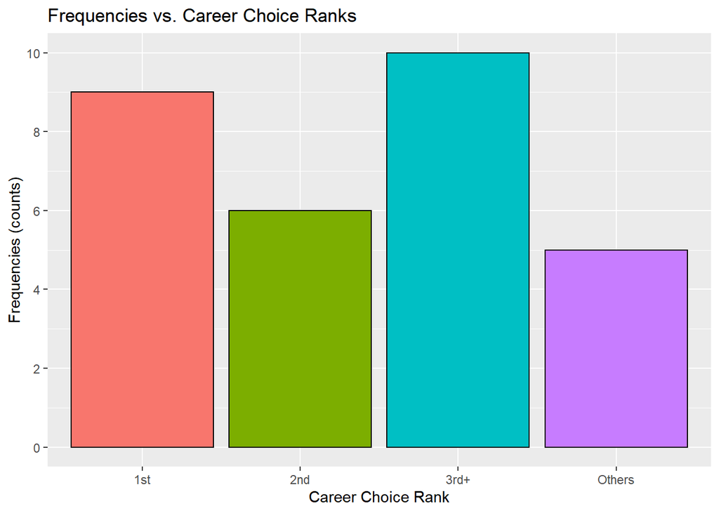

```r
library(ggplot2)
library(scales)

p1 <- ggplot(ds1, aes(x = Career.Choice.Rank, fill = Career.Choice.Rank)) +
  geom_bar(color = "black", show.legend = FALSE) +
  scale_fill_discrete() +
  scale_y_continuous(breaks = seq(0, max(table(ds1$Career.Choice.Rank)) + 5, 2)) +
  labs(
    title = "Frequencies vs. Career Choice Ranks",
    x = "Career Choice Rank",
    y = "Frequencies (counts)"
  )

print(p1)
```